# diagnosing a cloglog model

Ben Bolker

15:30 23 July 2017

Responding to a query from Rolf Turner on `r-sig-mixed-models@r-project.org`.

**tl;dr** the error messages are spurious/due to a singular fit. Considerable speed-ups can be achieved by (1) switching optimizers, (2) using `nAGQ=0`, (3) using `glmmTMB` or Julia …

**to do**

- compare variance-covariance matrix estimates (they vary a lot, although it doesn’t seem to have much effect on the fixed effects?
- play with/fight with Julia more (native mode rather than `rjulia` package? better retrieval of results? try `fast!` (corresponding to `nAGQ=0`)?
- worth comparing with `brms` results … ??
- try estimation with treatment and treatment-by-x effects either as real random effects (i.e., with shrinkage) *or* with large fixed variance (for computational efficiency)

**caveats**

```r
## fitting packages
library(lme4)
library(glmmTMB)
library(brms)
## post-analysis pkgs
library(broom)  ## need BMB version for glmmTMB
library(ggplot2); theme_set(theme_bw())
library(MASS) ## before dplyr; avoid masking dplyr::select()
library(dplyr)
library(tidyr)
library(ggstance)
```

To run the code in the Julia section below you need to install:

- Julia; tested on versions 0.5.2 and 0.6.0, I used 0.6.0 below. On Ubuntu you can

  ```
  sudo add-apt-repository ppa:staticfloat/juliareleases
  sudo apt-get update
  sudo apt-get install julia
  ```

- Doug Bates’s [MixedModels.jl](https://github.com/dmbates/MixedModels.jl/) package (in Julia, `Pkg.add(“MixedModels”)`)
- at present, an updated version of the `GLM` package for Julia that fixes an issue with the cloglog link (in Julia, `Pkg.checkout(“GLM”); Pkg.checkout(“GLM”, “db/clampcloglog”)`
- this example no longer uses the `rjulia` package for R. It did in previous versions; I needed to create a modified version (in R, `devtools::install_github(“bbolker/rjulia”, ref=“julia0.5”)`

```r
set.seed(42)
X <- artSim()
write.csv(X,file="artSim.csv",row.names=FALSE)
```

```r
t1 <- system.time(fit1 <- glmer(cbind(Dead,Alive) ~ (Trt + 0)/x + (x | Rep),
                        family=binomial(link="cloglog"),
                        data=X))
```

```
## Warning in (function (fn, par, lower = rep.int(-Inf, n), upper =
## rep.int(Inf, : failure to converge in 10000 evaluations
```

```
## Warning in checkConv(attr(opt, "derivs"), opt$par, ctrl = control
## $checkConv, : unable to evaluate scaled gradient
```

```
## Warning in checkConv(attr(opt, "derivs"), opt$par, ctrl = control
## $checkConv, : Model failed to converge: degenerate Hessian with 1 negative
## eigenvalues
```

```r
t2 <- system.time(fit2 <- update(fit1,control=glmerControl(optCtrl=list(maxfun=3e4))))
```

```
## Warning in checkConv(attr(opt, "derivs"), opt$par, ctrl = control
## $checkConv, : unable to evaluate scaled gradient
```

```
## Warning in checkConv(attr(opt, "derivs"), opt$par, ctrl = control
## $checkConv, : Model failed to converge: degenerate Hessian with 1 negative
## eigenvalues
```

Now we have just the post-fitting convergence warnings. The first thing we should do is to check for singularity: if the fit is singular, i.e. some of the $\theta$ (variance-covariance) parameters are at their constrained values, then the warning about negative eigenvalues of the Hessian is largely irrelevant (it is a long-term wish-list item to evaluate the [Karush-Kuhn-Tucker conditions](https://en.wikipedia.org/wiki/Karush%E2%80%93Kuhn%E2%80%93Tucker_conditions) properly in this case, i.e. allowing for the constraints.

```r
is.singular <- function(x,tol=1e-6) any(abs(getME(x,"theta"))<tol)
is.singular(fit2)
```

```
## [1] TRUE
```

Furthermore, in this case we can more simply look a the variance-covariance matrix and see that it has a zero variance (and an undefined correlation), which more directly indicates singularity.

```r
VarCorr(fit2)
```

```
##  Groups Name        Std.Dev. Corr
##  Rep    (Intercept) 0.000000
##         x           0.015276   NaN
```

I wanted to see if we could speed things up (without losing accuracy) by using the BOBYQA implementation from the `nloptr` package. It turns out that in order to do this, we have to skip the `nAGQ=0` init step (this is sometimes needed for cloglog models, especially those with offsets):

```r
t3 <- system.time(fit3 <- update(fit1,control=glmerControl(optimizer="nloptwrap",
                                                   nAGQ0initStep=FALSE)))
```

Unfortunately, skipping the init step gives a negative log-likelihood that is -74 log-likelihood units worse (!).

I tried `nAGQ0initStep=FALSE` with the default optimizer or the BOBYQA optimizer as well; it was very very slow ($\approx 600$ seconds with `maxfun=5e4`, which wasn’t even enough …)

```r
t4 <- system.time(fit4 <- update(fit1,
                                control=glmerControl(optimizer="bobyqa",
                                                     optCtrl=list(maxfun=1e5),
                                                     nAGQ0initStep=FALSE)))
```

What about the opposite (`nAGQ=0`), as suggested by Tony Ives?

```r
t5 <- system.time(fit5 <- update(fit1,nAGQ=0,control=glmerControl(optimizer="bobyqa",
                                                                  optCtrl=list(maxfun=3e4))))
```

Can’t use `nAGQ > 1` in this case because we have a random-slopes model … too bad. (We have a mean value of effective sample size = `min(alive,dead)` 3, which implies that the Gauss-Hermite quadrature corrections *should* be important, but …)

We can’t really compare the likelihoods with `nAGQ=0` vs. `nAGQ>0`, so we’ll just compare fixed-effect estimates (below).

```r
t6 <- system.time(fit6 <- glmmTMB(Dead/(Alive+Dead) ~ (Trt + 0)/x + (x | Rep),
                                  weights = Alive+Dead,
                                  family=binomial(link="cloglog"),data=X))
```

```r
t7 <- system.time(fit7 <- update(fit1,control=glmerControl(optimizer="bobyqa",
                                                           optCtrl=list(maxfun=3e4))))
```

## julia-lang

This is actually almost working, with a few caveats:

- I’m having trouble getting Julia to evaluate properly in an Rmarkdown chunk (can probably do this but will have to fight with it a bit)
  - the `runr`-based strategy implemented [here](https://rpubs.com/yihui/julia-knitr) is flaky
  - I could hack together something simpler based on sending text to Julia for evaluation (`rjulia -e`? `-E`?) but not sure how well it would work
  - `rjulia` works (if hacked as described above)
  - I fell back on simply running the Julia code (below, and here) as a separate process and printing the results to a file
- requires fix to Julia GLM internals so cloglog doesn’t underflow

```
using DataFrames, GLM, MixedModels
const df = readtable("artSim.csv", makefactors = true);
## compute proportions and totals
df[:Tot] = float.(df[:Dead]+df[:Alive]);
df[:prop] = df[:Dead] ./ df[:Tot];
## for CPU timing:
### Pkg.clone("https://github.com/schmrlng/CPUTime.jl.git")
## fit without timing, for compilation
## (Trt+0)/x formula notation doesn't work, need to expand it ourselves
g3 = fit!(glmm(@formula(prop ~ 0 + Trt + Trt&x + (1 + x|Rep)), df,
    Binomial(), CloglogLink(), wt=Array(df[:Tot])), fast = true);
e1 = @elapsed fit!(glmm(@formula(prop ~ 0 + Trt + Trt&x + (1 + x|Rep)), df,
    Binomial(), CloglogLink(), wt=Array(df[:Tot])), fast = true)
## non-fast (nAGQ>0)
e2 = @elapsed g4 = fit!(glmm(@formula(prop ~ 0 + Trt + Trt&x + (1 + x|Rep)), df,
    Binomial(), CloglogLink(), wt=Array(df[:Tot])))
## store timing info
open("julia_cloglog_timings.txt","w") do f
    write(f,string(e1)," ",string(e2),"\n")
end
## store fixed-effect results
ct = coeftable(g4)
outdf = DataFrame(variable = ct.rownms,
                 Estimate = ct.cols[1],
               StdError = ct.cols[2],
                z_val = ct.cols[3])
writetable("julia_cloglog_coefs.csv",outdf)
ct = coeftable(g3)
outdf = DataFrame(variable = ct.rownms,
                 Estimate = ct.cols[1],
               StdError = ct.cols[2],
                z_val = ct.cols[3])
writetable("julia_cloglog_coefs_nagq0.csv",outdf)
```

## brms

This `brms` fit works (sort of); it runs, but we get the following warnings:

```
1: The model has not converged (some Rhats are > 1.1). Do not analyse the results!
We recommend running more iterations and/or setting stronger priors.
2: There were 4000 divergent transitions after warmup. Increasing adapt_delta above 0.8 may help.
See http://mc-stan.org/misc/warnings.html#divergent-transitions-after-warmup
```

```r
t8 <- system.time(
    fit8 <- brm(Dead | trials(Dead+Alive) ~ (Trt + 0)/x + (x | Rep),
                family=binomial(link="cloglog"),
                inits="0",
                data=X))
```

Might work if we added some kind of priors (or group priors, i.e. shrinkage) on the fixed effects?

## results summary

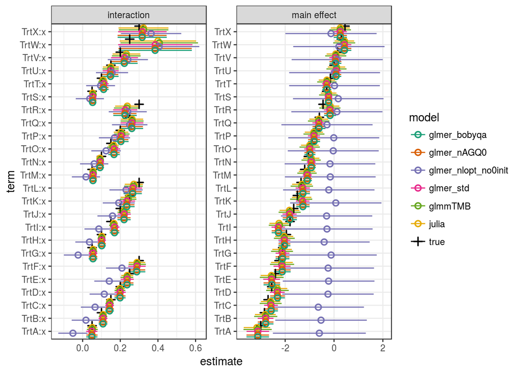

Or perhaps more clearly:

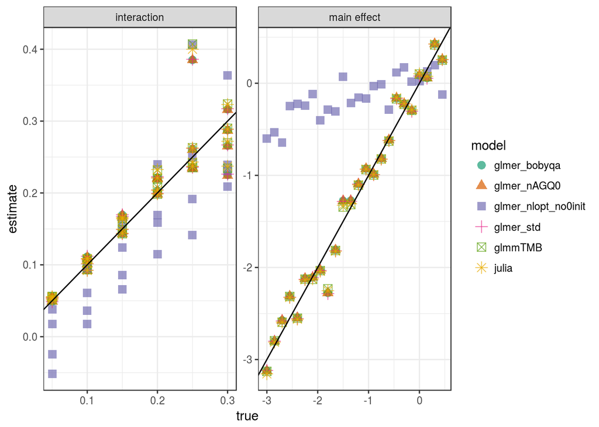

Check timings:

| model | elapsed |
| --- | --- |
| glmer_nAGQ0 | 0.763 |
| glmmTMB | 17.418 |
| glmer_bobyqa | 38.037 |
| glmer_nlopt_no0init | 82.309 |
| glmer_std | 97.393 |

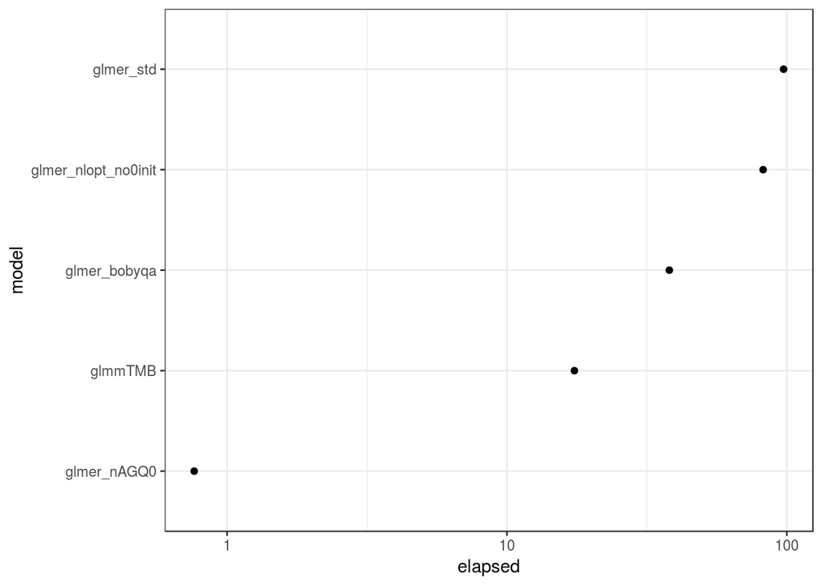

## julia-lang

- I’m having trouble getting Julia to evaluate properly in an Rmarkdown chunk (can probably do this but will have to fight with it a bit). The `runr`-based strategy implemented [here](https://rpubs.com/yihui/julia-knitr) *sort of* works, but is flaky. Could hack together something based on evaluation, or ?
- I can get things to work with the logit link, but the cloglog link underflows somewhere
- will need to work on pulling the results from julia back into the rest of the document for comparison …

```r
## {r juliafit,engine="julia",eval=FALSE,warning=FALSE}
jDo("using DataFrames")
jDo("using MixedModels")
jDo("using GLM")  ## for testing
jDo('df = readtable("artSim.csv");')
## compute proportions and totals
jDo('df[:tot] = df[:Dead]+df[:Alive];')
jDo('df[:prop] = df[:Dead] ./ df[:tot];')
## convert Treatment to categorical
## https://stackoverflow.com/questions/43708635/indicator-matrix-for-categorical-data-in-glm-jl-with-dataframes-jl
jDo('pool!(df, [:Trt])')
## working up to it ....
## g1 = glm(@formula(prop ~ Trt+0), df, Binomial(), CloglogLink(), wt= Array(df[:tot]));
## g2 = glmm(@formula(prop ~ Trt+0 + (1 | Rep)), df, Binomial(), wt = float.(Array(df[:tot])));
## g3 = glmm(@formula(prop ~ Trt+0 + (x | Rep)), df, Binomial(), wt = float.(Array(df[:tot])));
## can't handle (a+b)/x syntax ... expand ???
## g4 = glmm(@formula(prop ~ (Trt+0)/x + (x | Rep)), df, Binomial(), wt = float.(Array(df[:tot])));

## glmm(@formula(prop ~ 0+Trt+Trt&x + (x | Rep)), df, Binomial(),
##           CloglogLink(), wt = float.(Array(df[:tot])))
## ERROR: AssertionError: isfinite(crit)
##
jDo("@time g1 = glmm(@formula(prop ~ 0+Trt+Trt&x + (x | Rep)), df, Binomial(),
          LogitLink(), wt = float.(Array(df[:tot])));")
ff <- j2r("fixef(g1)")
rr <- j2r("ranef(g1)") ## NULL ???
```

[figure not shown]